# Ford Go Bike Trip DATA

### Overview

##### in this Analysis i want to see what is the common relation of the users characterstic and the effect on the trips duration they made i focused on top 12 trips made

### Data overlook

#### the data consist from trip trip info (start and end station and time) and user info (gender and birthyear and type)

## plot 1

### the plot of the top 12 trips made in the data

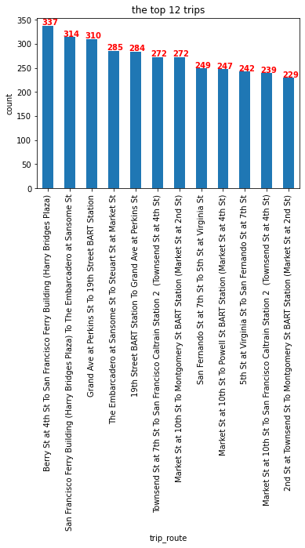

```python
#plot the data
the_trips_frame.plot(kind='bar',x='trip_route',legend=False)
for i,z in enumerate(the_trips_frame['count']):
    plt.text(i-.3,z+1.75,z,color='red',fontweight='bold')
plt.title('the top 12 trips')
plt.ylabel('count');
```

### you can find on x axis the name of trip start station to end station

### plot 2

##### now lets see the range of users age

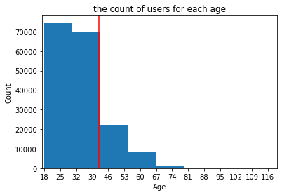

```python
binzz=np.arange(18,120,7)
plt.hist(df_clean_for_age['age'])
plt.xticks(binzz)
plt.xlim(17,120)
plt.axvline(42,color='r')
plt.title('the count of users for each age')
plt.xlabel('Age')
plt.ylabel('Count')
```

##### you can see before the red line at age 42 the bigger count of our users fall so the range is from 18 to 42

### plot 3

### now lets see the correlation between age and duration in min for the whole data

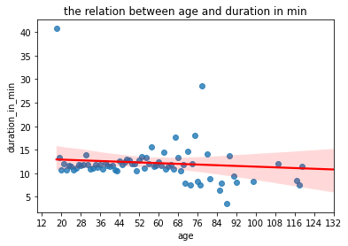

```python
binz1=np.arange(12,135,8)
sb.regplot(data=age_frame,x='age',y='duration_in_min',line_kws={'color':'r'})
plt.xlim(10,130)
plt.xticks(binz1);
plt.title('the relation between age and duration in min');
```

#### there is a weak relation between them we can conclude that what ever the customer age he will take the same time in his trip

### plot 4

### now let`s see the correlation again between age and duration for each of our top 12 trip

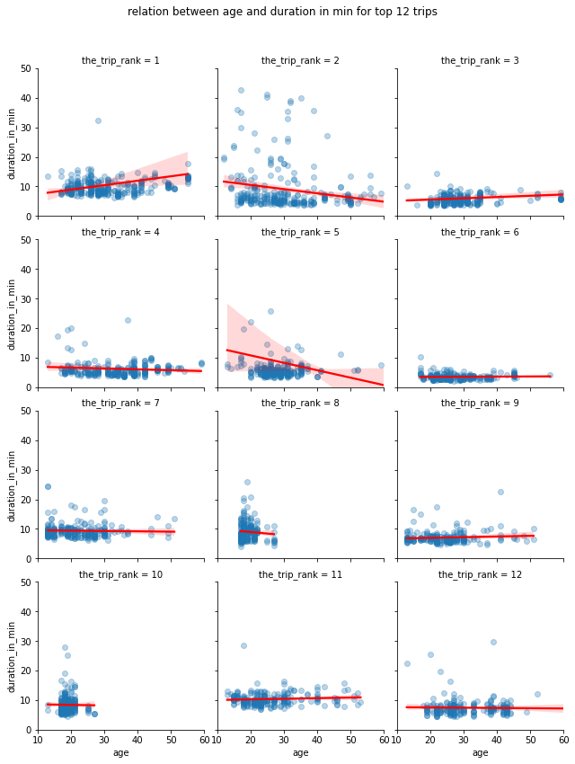

```python
#remove outliere from our groph and set limit to 50
h=sb.FacetGrid(data=top_frame,col='the_trip_rank',col_wrap=3,legend_out=True)
h.map(sb.regplot,'age','duration_in_min',line_kws={'color':'r'},scatter_kws={'alpha':.3})
plt.ylim((0,50))
plt.xlim(10,60)
h.fig.subplots_adjust(top=0.9)
h.fig.suptitle('relation between age and duration in min for top 12 trips');
```

#### we can see that the correlation still weak but the range of our customer is limited at top 8 and top 10 trips

### plot 5

### what the customer gender for those 12 trip are the most of them are male or females and what the age of those customer

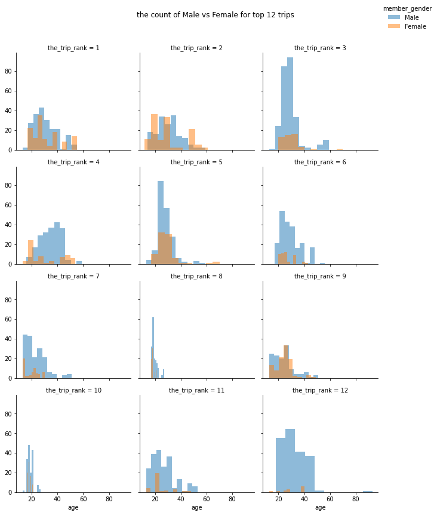

```python
#ploting the data
h=sb.FacetGrid(data=top_frame_for_gender,hue='member_gender',col='the_trip_rank',col_wrap=3,legend_out=True)
h.map(plt.hist,'age',alpha=.5)
h.fig.subplots_adjust(top=0.9)
h.fig.suptitle('the count of Male vs Female for top 12 trips')
h.add_legend(loc=1)
```

#### the male customers have the most count in all of trips and at every age too expect a very few times

### plot 6

#### what if the customer is male or female if this will affect the relation between age and time for each top 12 trip

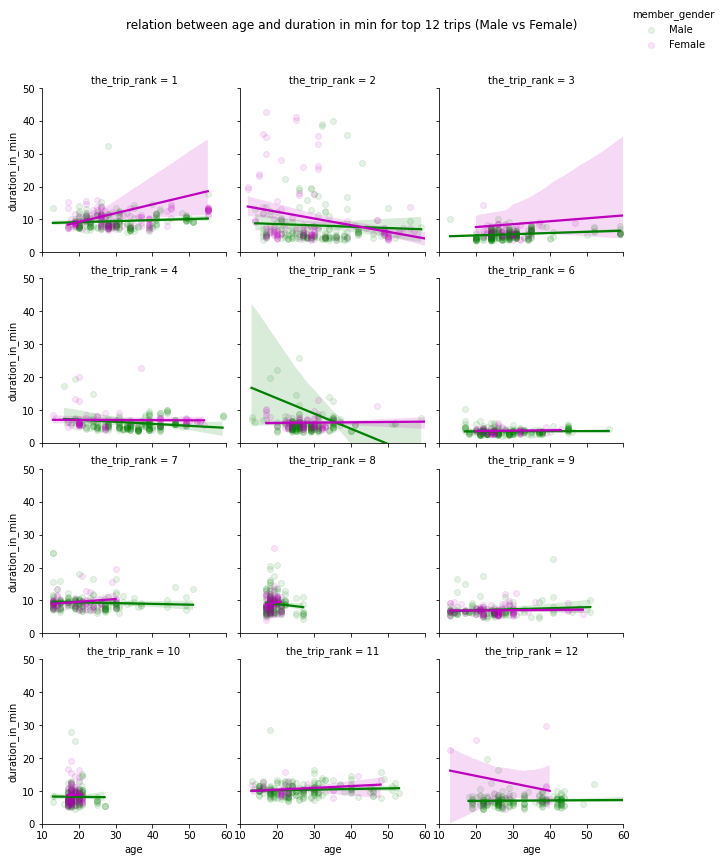

```python
k=sb.FacetGrid(data=top_frame_for_gender,col='the_trip_rank',hue='member_gender',col_wrap=3,legend_out=True,palette={'Male':'g','Female':'m'})
k.map(sb.regplot,'age','duration_in_min',scatter_kws={'alpha':.1},line_kws={'alpha':1})
plt.ylim((0,50))
plt.xlim(10,60)
k.fig.subplots_adjust(top=0.9)
k.fig.suptitle('relation between age and duration in min for top 12 trips (Male vs Female)')
k.add_legend(loc=1)
```

#### it looks like that rank 5 trip male users trip duration are getting too much lower when theg getting older

#### that is because the count of users are getting lower at this trip we can see that at plot 5

### plot 7

### user type is this will affect the correlatin or not

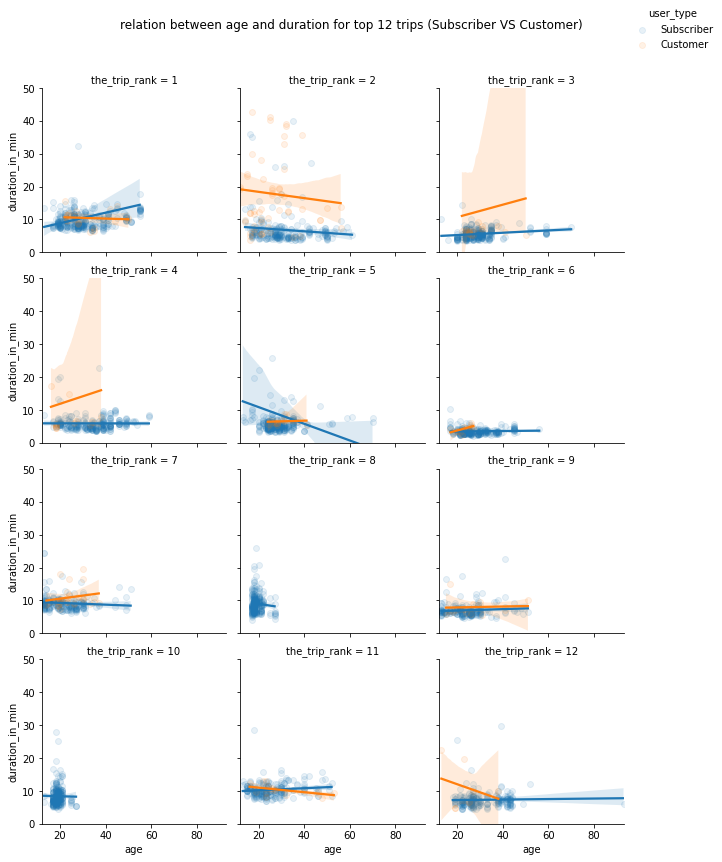

```python
l=sb.FacetGrid(data=top_frame,col='the_trip_rank',col_wrap=3,hue='user_type')
l.map(sb.regplot,'age','duration_in_min',scatter_kws={'alpha':.1},line_kws={'alpha':1})
plt.ylim(0,50)
l.add_legend(loc=1)
l.fig.subplots_adjust(top=0.9)
l.fig.suptitle('relation between age and duration for top 12 trips (Subscriber VS Customer)')
```